# outline and central results - CAM in mediation

Julius Fenn, idea by Wilhelm Gros

30 03 2023

# 1 Outline

- additional to mean_valence of CAMs, we have multiple other (dependent) variables
  - multiple outcome variables (dummy, perceived acceptability)
  - multiple scales of the “Technology Acceptance Model”
  - PANAS Scale
  - general feelings about technology (livmats related questions)
  - multiple network indicators
- two general procedures of analysis are possible:
  - **quantitative:** test multiple models (multivariate multilevel models or mixed ANOVAs) regarding the mixed design
  - **qualitative:** summarize CAM data followed by *graph alignment* to check which specific areas of concepts (superordinate topics) have changed after the treatment
  - plus present usefullness of CAM method descriptively (e.g. aggregated CAM, discussion of general concerns)

# 2 Central Results

## 2.1 Descriptive

```r
## matching conditions (time X treatment)
table(dat_long$idcodegroup, dat_long$timepoint)
```

```
##
##             0  1
##   control  40 40
##   negative 17 17
##   positive 18 18
```

- just for illustration I include only 2 variables in the following analyses:

**mean_valence**

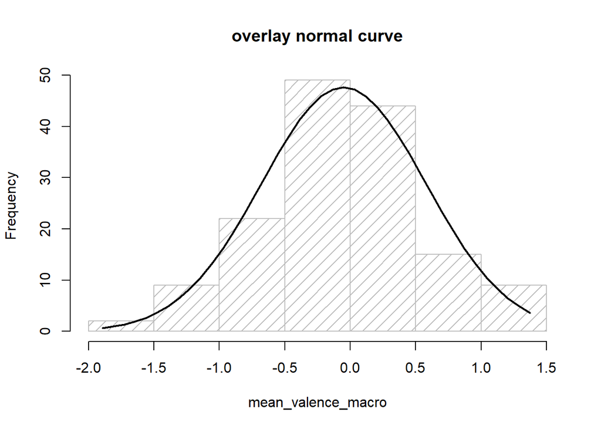

```r
g <- dat_long$mean_valence_macro
h <- hist(g, breaks = 10, density = 10,
          col = "gray", xlab = "mean_valence_macro", main = "overlay normal curve")
xfit <- seq(min(g), max(g), length = 40)
yfit <- dnorm(xfit, mean = mean(g), sd = sd(g))
yfit <- yfit * diff(h$mids[1:2]) * length(g)

lines(xfit, yfit, col = "black", lwd = 2)
```

**fc_panas_neg** which are computed factor scores of the negative emotion items of PANAS (using polychoric correlations to account for the non-normality of items, factor score computed using method Bartlett)

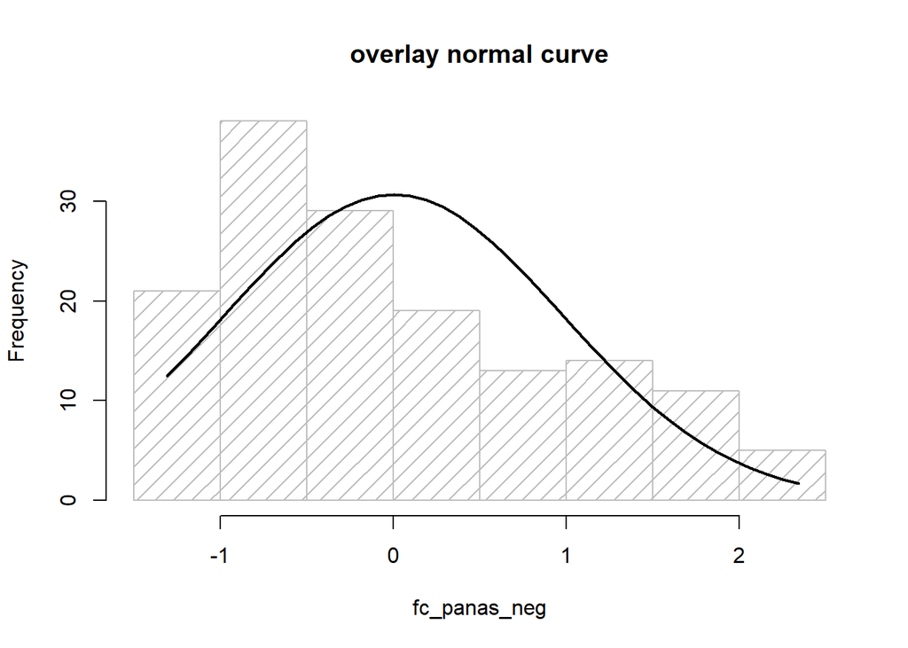

```r
g <- dat_long$fc_panas_neg
h <- hist(g, breaks = 10, density = 10,
          col = "gray", xlab = "fc_panas_neg", main = "overlay normal curve")
xfit <- seq(min(g), max(g), length = 40)
yfit <- dnorm(xfit, mean = mean(g), sd = sd(g))
yfit <- yfit * diff(h$mids[1:2]) * length(g)

lines(xfit, yfit, col = "black", lwd = 2)
```

```r
dat_long$idcodegroup <- factor(dat_long$idcodegroup)
dat_long %>%
  group_by(timepoint, idcodegroup) %>%
  dplyr::summarise(mean = mean(mean_valence_macro))
```

```
## # A tibble: 6 × 3
## # Groups:   timepoint [2]
##   timepoint idcodegroup      mean
##       <dbl> <fct>           <dbl>
## 1         0 control     -0.114
## 2         0 negative    -0.587
## 3         0 positive     0.384
## 4         1 control      0.0765
## 5         1 negative     0.000967
## 6         1 positive    -0.174
```

## 2.2 multivariate multilevel models

*motivation using these kind of models: when computing ANOVAs in the context of regression models (= multivariate multilevel models) we do not need to run any post-hoc test anymore and in theory can compute more complex interactions of even latent regressions, for example, by applying so called latent change score models*

```r
# mean difference between fixed occasions model for 3 groups:
mmm1 <- lme(mean_valence_macro ~ 1 + post*idcodegroup_positive +
              post*idcodegroup_negative,
            random = ~ 1 + post | prolific_pid,
            data = dat_long,
            control=list(sigma=1e-10, opt="optim"))

summary(mmm1)
```

```
## Linear mixed-effects model fit by REML
##   Data: dat_long
##        AIC      BIC    logLik
##   797.0358 823.7641 -389.5179
##
## Random effects:
##  Formula: ~1 + post | prolific_pid
##  Structure: General positive-definite, Log-Cholesky parametrization
##             StdDev       Corr
## (Intercept) 0.5084585570 (Intr)
## post        0.5833364367 -0.288
## Residual    0.0000000001
##
## Fixed effects:  mean_valence_macro ~ 1 + post * idcodegroup_positive + post *      idcodegroup_negative
##                                Value  Std.Error DF   t-value p-value
## (Intercept)               -0.1143336 0.08039436 72 -1.422160  0.1593
## post                       0.1908583 0.09223359 72  2.069292  0.0421
## idcodegroup_positive       0.4986140 0.14431229 72  3.455104  0.0009
## idcodegroup_negative      -0.4731240 0.14721041 72 -3.213930  0.0020
## post:idcodegroup_positive -0.7487482 0.16556436 72 -4.522400  0.0000
## post:idcodegroup_negative  0.3975660 0.16888928 72  2.354004  0.0213
##  Correlation:
##                           (Intr) post   idcdgrp_p idcdgrp_n pst:dcdgrp_p
## post                      -0.288
## idcodegroup_positive      -0.557  0.160
## idcodegroup_negative      -0.546  0.157  0.304
## post:idcodegroup_positive  0.160 -0.557 -0.288    -0.088
## post:idcodegroup_negative  0.157 -0.546 -0.088    -0.288     0.304
##
## Standardized Within-Group Residuals:
##           Min            Q1           Med            Q3           Max
## -2.220446e-06 -5.551115e-07  0.000000e+00  5.551115e-07  5.551115e-06
##
## Number of Observations: 150
## Number of Groups: 75
```

```r
# add Level-2 predictor fc_panas_neg
mmm2 <- lme(mean_valence_macro ~ 1 + post*idcodegroup_positive +
              post*idcodegroup_negative + post*fc_panas_neg,
            random = ~ 1 + post | prolific_pid,
            data = dat_long,
            control=list(sigma=1e-10, opt="optim"))

summary(mmm2)
```

```
## Linear mixed-effects model fit by REML
##   Data: dat_long
##        AIC      BIC    logLik
##   969.4774 1001.992 -473.7387
##
## Random effects:
##  Formula: ~1 + post | prolific_pid
##  Structure: General positive-definite, Log-Cholesky parametrization
##             StdDev       Corr
## (Intercept) 0.4900806581 (Intr)
## post        0.5803607832 -0.386
## Residual    0.0000000001
##
## Fixed effects:  mean_valence_macro ~ 1 + post * idcodegroup_positive + post *      idcodegroup_negative + post * fc_panas_neg
##                                Value  Std.Error DF   t-value p-value
## (Intercept)               -0.1202575 0.07753866 72 -1.550936  0.1253
## post                       0.1508458 0.09251567 70  1.630489  0.1075
## idcodegroup_positive       0.5151158 0.13931273 72  3.697550  0.0004
## idcodegroup_negative      -0.4418965 0.14264824 72 -3.097806  0.0028
## fc_panas_neg              -0.1235793 0.05814346 70 -2.125420  0.0371
## post:idcodegroup_positive -0.7579656 0.16488576 70 -4.596914  0.0000
## post:idcodegroup_negative  0.5164264 0.17235806 70  2.996242  0.0038
## post:fc_panas_neg         -0.1220973 0.07320180 70 -1.667954  0.0998
##  Correlation:
##                           (Intr) post   idcdgrp_p idcdgrp_n fc_pn_ pst:dcdgrp_p
## post                      -0.382
## idcodegroup_positive      -0.558  0.212
## idcodegroup_negative      -0.547  0.207  0.308
## fc_panas_neg               0.036  0.011 -0.056    -0.103
## post:idcodegroup_positive  0.216 -0.553 -0.387    -0.121     0.043
## post:idcodegroup_negative  0.206 -0.556 -0.115    -0.375     0.013  0.299
## post:fc_panas_neg         -0.019  0.103  0.029     0.053    -0.515 -0.032
##                           pst:dcdgrp_n
## post
## idcodegroup_positive
## idcodegroup_negative
## fc_panas_neg
## post:idcodegroup_positive
## post:idcodegroup_negative
## post:fc_panas_neg         -0.197
##
## Standardized Within-Group Residuals:
##           Min            Q1           Med            Q3           Max
## -3.885781e-06 -5.551115e-07  0.000000e+00  1.110223e-06  6.661338e-06
##
## Number of Observations: 150
## Number of Groups: 75
```

**visualize results** for participants who had drawn a negative CAM and a positive prototype was presented

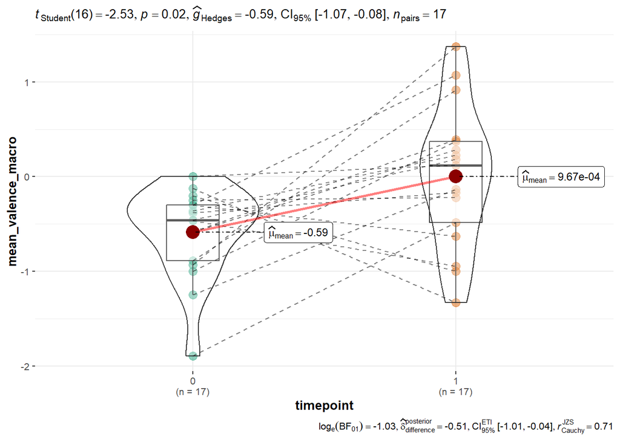

```r
# create a plot
p <- ggwithinstats(
  data = filter(dat_long, idcodegroup == "negative"),
  x    = timepoint,
  y    = mean_valence_macro,
  type = "p"
)
# looking at the plot
p
```

for participants who had drawn a positive CAM and a negative prototype was presented

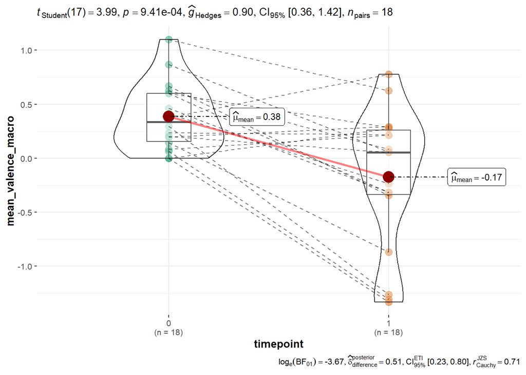

```r
# create a plot
p <- ggwithinstats(
  data = filter(dat_long, idcodegroup == "positive"),
  x    = timepoint,
  y    = mean_valence_macro,
  type = "p"
)
# looking at the plot
p
```

for participants where no prototype was presented

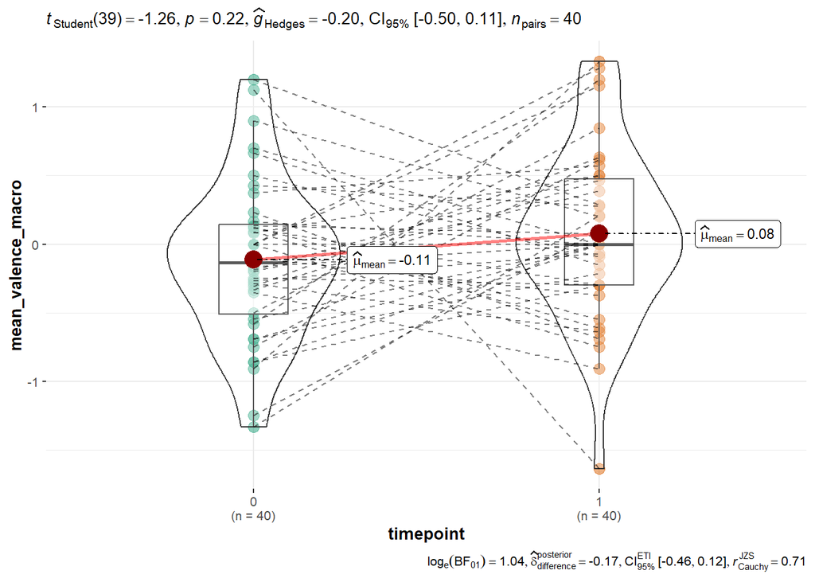

```r
# create a plot
p <- ggwithinstats(
  data = filter(dat_long, idcodegroup == "control"),
  x    = timepoint,
  y    = mean_valence_macro,
  type = "p"
)
# looking at the plot
p
```

### 2.2.1 for different dependend variables

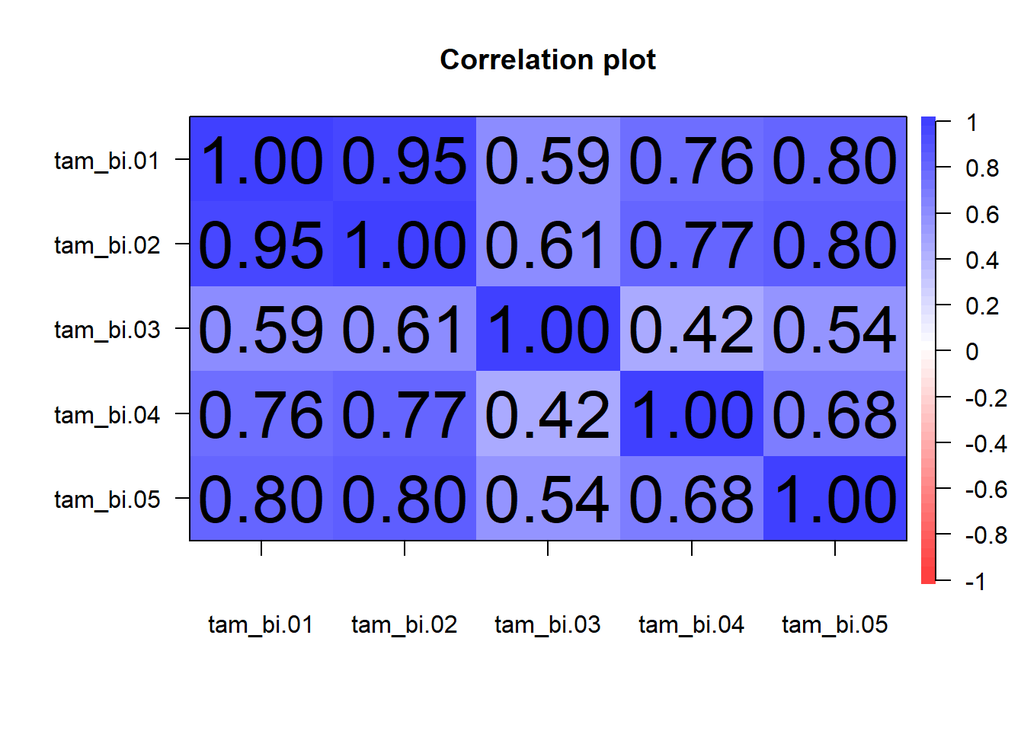

```r
cor.plot(r = cor(dat_long[, str_subset(string = colnames(dat_long), pattern = "tam_bi")]))
```

```r
dat_long$mean_tam_bi <- rowMeans(x = dat_long[, str_subset(string = colnames(dat_long), pattern = "tam_bi")])

# mean difference between fixed occasions model for 3 groups:
mmm1_ddv <- lme(mean_tam_bi ~ 1 + post*idcodegroup_positive +
              post*idcodegroup_negative,
            random = ~ 1 + post | prolific_pid,
            data = dat_long,
            control=list(sigma=1e-10, opt="optim"))

summary(mmm1_ddv)
```

```
## Linear mixed-effects model fit by REML
##   Data: dat_long
##        AIC      BIC    logLik
##   1063.606 1090.335 -522.8032
##
## Random effects:
##  Formula: ~1 + post | prolific_pid
##  Structure: General positive-definite, Log-Cholesky parametrization
##             StdDev       Corr
## (Intercept) 1.6583539355 (Intr)
## post        1.1787732798 -0.38
## Residual    0.0000000001
##
## Fixed effects:  mean_tam_bi ~ 1 + post * idcodegroup_positive + post * idcodegroup_negative
##                               Value Std.Error DF   t-value p-value
## (Intercept)                3.925000 0.2622088 72 14.968988  0.0000
## post                       0.035000 0.1863804 72  0.187788  0.8516
## idcodegroup_positive       0.463889 0.4706792 72  0.985573  0.3276
## idcodegroup_negative      -0.795588 0.4801315 72 -1.657022  0.1019
## post:idcodegroup_positive -0.112778 0.3345631 72 -0.337090  0.7370
## post:idcodegroup_negative  0.412059 0.3412819 72  1.207386  0.2312
##  Correlation:
##                           (Intr) post   idcdgrp_p idcdgrp_n pst:dcdgrp_p
## post                      -0.380
## idcodegroup_positive      -0.557  0.211
## idcodegroup_negative      -0.546  0.207  0.304
## post:idcodegroup_positive  0.211 -0.557 -0.380    -0.115
## post:idcodegroup_negative  0.207 -0.546 -0.115    -0.380     0.304
##
## Standardized Within-Group Residuals:
##           Min            Q1           Med            Q3           Max
## -1.776357e-05 -8.881784e-06  0.000000e+00  1.665335e-06  1.776357e-05
##
## Number of Observations: 150
## Number of Groups: 75
```

## 2.3 mixed ANOVA

we get identical results to multivariate multilevel models, but also estimates for generalized and partial eta squared (effect sizes), which are nice to report if anyone in the future wants to do a meta-analysis on our results (recommendation of Daniel Lakens)

**mixed ANOVA**

```r
fit1 <- afex::aov_car(mean_valence_macro ~ timepoint*idcodegroup + Error(prolific_pid / timepoint),
                      data = dat_long)
```

```
## Contrasts set to contr.sum for the following variables: idcodegroup
```

```r
fit1a <- afex::aov_ez(id = "prolific_pid", dv = "mean_valence_macro",
                      data = dat_long, between=c("idcodegroup"), within=c("timepoint"))
```

```
## Contrasts set to contr.sum for the following variables: idcodegroup
```

```r
# partical eta squared
anova(fit1, es = "pes")
```

```
## Anova Table (Type 3 tests)
##
## Response: mean_valence_macro
##                       num Df den Df     MSE       F     pes    Pr(>F)
## idcodegroup                2     72 0.51638  2.8637 0.07369   0.06358 .
## timepoint                  1     72 0.17014  1.0335 0.01415   0.31275
## idcodegroup:timepoint      2     72 0.17014 17.8915 0.33199 4.922e-07 ***
## ---
## Signif. codes:  0 '***' 0.001 '**' 0.01 '*' 0.05 '.' 0.1 ' ' 1
```

```r
# generalized eta squared
fit1a # > identical results
```

```
## Anova Table (Type 3 tests)
##
## Response: mean_valence_macro
##                  Effect    df  MSE         F  ges p.value
## 1           idcodegroup 2, 72 0.52    2.86 + .056    .064
## 2             timepoint 1, 72 0.17      1.03 .004    .313
## 3 idcodegroup:timepoint 2, 72 0.17 17.89 *** .110   <.001
## ---
## Signif. codes:  0 '***' 0.001 '**' 0.01 '*' 0.05 '+' 0.1 ' ' 1
```

**visualize results**

```r
dfvalcor <- data_summary(dat_long, varname="mean_valence_macro",
                         groupnames=c("timepoint","idcodegroup"))
```

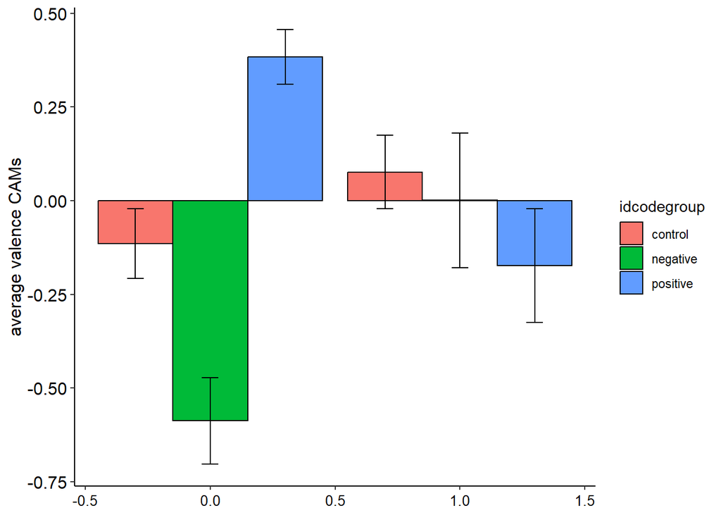

```r
p <- ggplot(dfvalcor, aes(x=timepoint, y=mean_valence_macro, fill=idcodegroup)) +
  geom_bar(stat="identity", color="black",
           position=position_dodge()) +
  geom_errorbar(aes(ymin=mean_valence_macro-se, ymax=mean_valence_macro+se), width=.2,
                position=position_dodge(.9)) + ggplot_theme + ylab(label = "average valence CAMs")
print(p)
```

**run post hoc tests**

```r
# Effect of group at each time point
one.way <- dat_long %>%
  group_by(timepoint) %>%
  anova_test(dv = mean_valence_macro, wid = prolific_pid, between = idcodegroup) %>%
  get_anova_table() %>%
  adjust_pvalue(method = "bonferroni")
one.way
```

```
## # A tibble: 2 × 9
##   timepoint Effect        DFn   DFd      F          p `p<.05`   ges      p.adj
##       <dbl> <chr>       <dbl> <dbl>  <dbl>      <dbl> <chr>   <dbl>      <dbl>
## 1         0 idcodegroup     2    72 16.0   0.00000179 "*"     0.308 0.00000358
## 2         1 idcodegroup     2    72  0.907 0.408      ""      0.025 0.816
```

```r
# Pairwise comparisons between group levels
pwc <- dat_long %>%
  group_by(timepoint) %>%
  pairwise_t_test(mean_valence_macro ~ idcodegroup, p.adjust.method = "bonferroni")
pwc
```

```
## # A tibble: 6 × 10
##   timepoint .y.               group1 group2    n1    n2       p p.signif   p.adj
## *     <dbl> <chr>             <chr>  <chr>  <int> <int>   <dbl> <chr>      <dbl>
## 1         0 mean_valence_mac… contr… negat…    40    17 1.96e-3 **       5.88e-3
## 2         0 mean_valence_mac… contr… posit…    40    18 9.26e-4 ***      2.78e-3
## 3         0 mean_valence_mac… negat… posit…    17    18 3   e-7 ****     8.99e-7
## 4         1 mean_valence_mac… contr… negat…    40    17 6.91e-1 ns       1   e+0
## 5         1 mean_valence_mac… contr… posit…    40    18 1.82e-1 ns       5.46e-1
## 6         1 mean_valence_mac… negat… posit…    17    18 4.33e-1 ns       1   e+0
## # ℹ 1 more variable: p.adj.signif <chr>
```

## 2.4 mixed ANOVA - tam_bi

**mixed ANOVA**

```r
fit1 <- afex::aov_car(mean_tam_bi ~ timepoint*idcodegroup + Error(prolific_pid / timepoint),
                      data = dat_long)
```

```
## Contrasts set to contr.sum for the following variables: idcodegroup
```

```r
fit1a <- afex::aov_ez(id = "prolific_pid", dv = "mean_tam_bi",
                      data = dat_long, between=c("idcodegroup"), within=c("timepoint"))
```

```
## Contrasts set to contr.sum for the following variables: idcodegroup
```

```r
# partical eta squared
anova(fit1, es = "pes")
```

```
## Anova Table (Type 3 tests)
##
## Response: mean_tam_bi
##                       num Df den Df    MSE      F      pes Pr(>F)
## idcodegroup                2     72 4.7113 1.8682 0.049334 0.1618
## timepoint                  1     72 0.6948 0.8439 0.011586 0.3613
## idcodegroup:timepoint      2     72 0.6948 1.0023 0.027087 0.3721
```

```r
# generalized eta squared
fit1a # > identical results
```

```
## Anova Table (Type 3 tests)
##
## Response: mean_tam_bi
##                  Effect    df  MSE    F  ges p.value
## 1           idcodegroup 2, 72 4.71 1.87 .043    .162
## 2             timepoint 1, 72 0.69 0.84 .002    .361
## 3 idcodegroup:timepoint 2, 72 0.69 1.00 .004    .372
## ---
## Signif. codes:  0 '***' 0.001 '**' 0.01 '*' 0.05 '+' 0.1 ' ' 1
```

**visualize results**

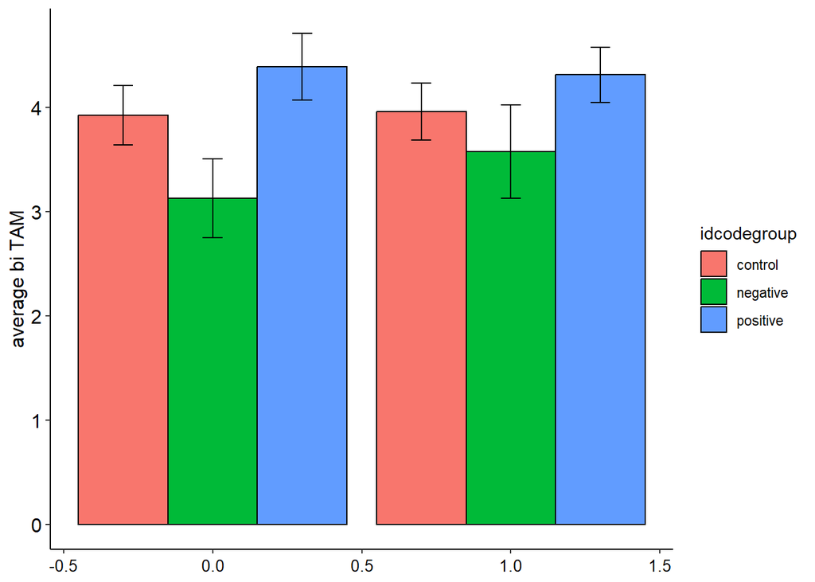

```r
dfvalcor <- data_summary(dat_long, varname="mean_tam_bi",
                         groupnames=c("timepoint","idcodegroup"))
p <- ggplot(dfvalcor, aes(x=timepoint, y=mean_tam_bi, fill=idcodegroup)) +
  geom_bar(stat="identity", color="black",
           position=position_dodge()) +
  geom_errorbar(aes(ymin=mean_tam_bi-se, ymax=mean_tam_bi+se), width=.2,
                position=position_dodge(.9)) + ggplot_theme + ylab(label = "average bi TAM")
print(p)
```

**run post hoc tests**

```r
# Effect of group at each time point
one.way <- dat_long %>%
  group_by(timepoint) %>%
  anova_test(dv = mean_tam_bi, wid = prolific_pid, between = idcodegroup) %>%
  get_anova_table() %>%
  adjust_pvalue(method = "bonferroni")
one.way
```

```
## # A tibble: 2 × 9
##   timepoint Effect        DFn   DFd     F     p `p<.05`   ges p.adj
##       <dbl> <chr>       <dbl> <dbl> <dbl> <dbl> <chr>   <dbl> <dbl>
## 1         0 idcodegroup     2    72 2.60  0.082 ""      0.067 0.164
## 2         1 idcodegroup     2    72 0.888 0.416 ""      0.024 0.832
```

```r
# Pairwise comparisons between group levels
pwc <- dat_long %>%
  group_by(timepoint) %>%
  pairwise_t_test(mean_tam_bi ~ idcodegroup, p.adjust.method = "bonferroni")
pwc
```

```
## # A tibble: 6 × 10
##   timepoint .y.    group1 group2    n1    n2      p p.signif  p.adj p.adj.signif
## *     <dbl> <chr>  <chr>  <chr>  <int> <int>  <dbl> <chr>     <dbl> <chr>
## 1         0 mean_… contr… negat…    40    17 0.102  ns       0.306  ns
## 2         0 mean_… contr… posit…    40    18 0.328  ns       0.983  ns
## 3         0 mean_… negat… posit…    17    18 0.0278 *        0.0834 ns
## 4         1 mean_… contr… negat…    40    17 0.419  ns       1      ns
## 5         1 mean_… contr… posit…    40    18 0.45   ns       1      ns
## 6         1 mean_… negat… posit…    17    18 0.187  ns       0.56   ns
```

### 2.4.1 mixed

```r
tmp <- dat_long[dat_long$timepoint == 0,]
cor(tmp$mean_tam_bi, tmp$mean_valence_macro)
```

```
## [1] 0.4685966
```

```r
tmp <- dat_long[dat_long$timepoint == 1,]
cor(tmp$mean_tam_bi, tmp$mean_valence_macro)
```

```
## [1] 0.3662753
```

```r
dat_long %>%
  group_by(timepoint, idcodegroup) %>%
  dplyr::summarise(mean = mean(mean_tam_bi))
```

```
## # A tibble: 6 × 3
## # Groups:   timepoint [2]
##   timepoint idcodegroup  mean
##       <dbl> <fct>       <dbl>
## 1         0 control      3.92
## 2         0 negative     3.13
## 3         0 positive     4.39
## 4         1 control      3.96
## 5         1 negative     3.58
## 6         1 positive     4.31
```

## 2.5 mixed ANOVA - number of concepts

**mixed ANOVA**

```r
fit1 <- afex::aov_car(num_nodes_macro ~ timepoint*idcodegroup + Error(prolific_pid / timepoint),
                      data = dat_long)
```

```
## Contrasts set to contr.sum for the following variables: idcodegroup
```

```r
fit1a <- afex::aov_ez(id = "prolific_pid", dv = "num_nodes_macro",
                      data = dat_long, between=c("idcodegroup"), within=c("timepoint"))
```

```
## Contrasts set to contr.sum for the following variables: idcodegroup
```

```r
# partical eta squared
anova(fit1, es = "pes")
```

```
## Anova Table (Type 3 tests)
##
## Response: num_nodes_macro
##                       num Df den Df    MSE       F     pes    Pr(>F)
## idcodegroup                2     72 40.611  2.8118 0.07245   0.06671 .
## timepoint                  1     72  6.822 49.5444 0.40762 9.375e-10 ***
## idcodegroup:timepoint      2     72  6.822 15.0817 0.29525 3.383e-06 ***
## ---
## Signif. codes:  0 '***' 0.001 '**' 0.01 '*' 0.05 '.' 0.1 ' ' 1
```

```r
# generalized eta squared
fit1a # > identical results
```

```
## Anova Table (Type 3 tests)
##
## Response: num_nodes_macro
##                  Effect    df   MSE         F  ges p.value
## 1           idcodegroup 2, 72 40.61    2.81 + .063    .067
## 2             timepoint 1, 72  6.82 49.54 *** .090   <.001
## 3 idcodegroup:timepoint 2, 72  6.82 15.08 *** .057   <.001
## ---
## Signif. codes:  0 '***' 0.001 '**' 0.01 '*' 0.05 '+' 0.1 ' ' 1
```

**visualize results**

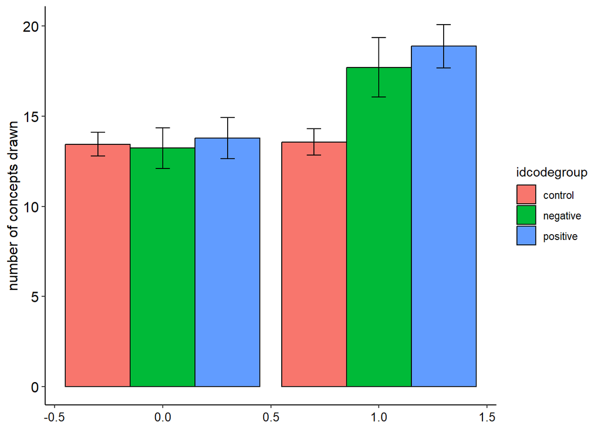

```r
dfvalcor <- data_summary(dat_long, varname="num_nodes_macro",
                         groupnames=c("timepoint","idcodegroup"))
p <- ggplot(dfvalcor, aes(x=timepoint, y=num_nodes_macro, fill=idcodegroup)) +
  geom_bar(stat="identity", color="black",
           position=position_dodge()) +
  geom_errorbar(aes(ymin=num_nodes_macro-se, ymax=num_nodes_macro+se), width=.2,
                position=position_dodge(.9)) + ggplot_theme + ylab(label = "number of concepts drawn")
print(p)
```

**run post hoc tests**

```r
# Effect of group at each time point
one.way <- dat_long %>%
  group_by(timepoint) %>%
  anova_test(dv = num_nodes_macro, wid = prolific_pid, between = idcodegroup) %>%
  get_anova_table() %>%
  adjust_pvalue(method = "bonferroni")
one.way
```

```
## # A tibble: 2 × 9
##   timepoint Effect        DFn   DFd     F        p `p<.05`   ges   p.adj
##       <dbl> <chr>       <dbl> <dbl> <dbl>    <dbl> <chr>   <dbl>   <dbl>
## 1         0 idcodegroup     2    72 0.068 0.934    ""      0.002 1
## 2         1 idcodegroup     2    72 7.71  0.000925 "*"     0.176 0.00185
```

```r
# Pairwise comparisons between group levels
pwc <- dat_long %>%
  group_by(timepoint) %>%
  pairwise_t_test(num_nodes_macro ~ idcodegroup, p.adjust.method = "bonferroni")
pwc
```

```
## # A tibble: 6 × 10
##   timepoint .y.             group1   group2    n1    n2       p p.signif   p.adj
## *     <dbl> <chr>           <chr>    <chr>  <int> <int>   <dbl> <chr>      <dbl>
## 1         0 num_nodes_macro control  negat…    40    17 8.67e-1 ns       1
## 2         0 num_nodes_macro control  posit…    40    18 7.94e-1 ns       1
## 3         0 num_nodes_macro negative posit…    17    18 7.17e-1 ns       1
## 4         1 num_nodes_macro control  negat…    40    17 8.71e-3 **       0.0261
## 5         1 num_nodes_macro control  posit…    40    18 7.08e-4 ***      0.00212
## 6         1 num_nodes_macro negative posit…    17    18 5.11e-1 ns       1
## # ℹ 1 more variable: p.adj.signif <chr>
```

**visualize results** - negative concepts

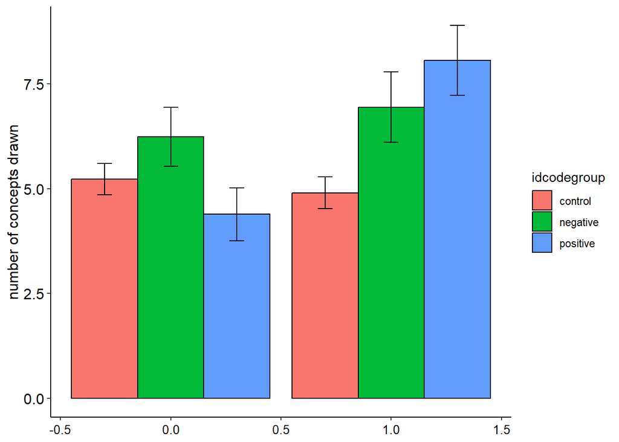

```r
dfvalcor <- data_summary(dat_long, varname="num_nodes_neg_macro",
                         groupnames=c("timepoint","idcodegroup"))
p <- ggplot(dfvalcor, aes(x=timepoint, y=num_nodes_neg_macro, fill=idcodegroup)) +
  geom_bar(stat="identity", color="black",
           position=position_dodge()) +
  geom_errorbar(aes(ymin=num_nodes_neg_macro-se, ymax=num_nodes_neg_macro+se), width=.2,
                position=position_dodge(.9)) + ggplot_theme + ylab(label = "number of concepts drawn")
print(p)
```

**visualize results** - positive concepts

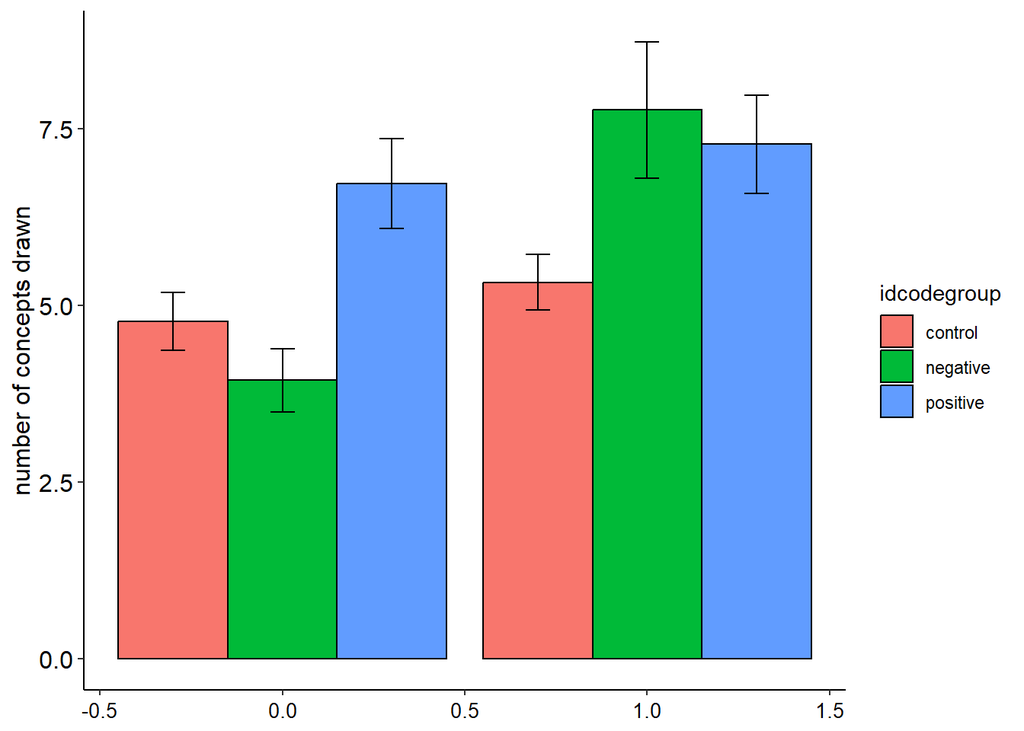

```r
dfvalcor <- data_summary(dat_long, varname="num_nodes_pos_macro",
                         groupnames=c("timepoint","idcodegroup"))
p <- ggplot(dfvalcor, aes(x=timepoint, y=num_nodes_pos_macro, fill=idcodegroup)) +
  geom_bar(stat="identity", color="black",
           position=position_dodge()) +
  geom_errorbar(aes(ymin=num_nodes_pos_macro-se, ymax=num_nodes_pos_macro+se), width=.2,
                position=position_dodge(.9)) + ggplot_theme + ylab(label = "number of concepts drawn")
print(p)
```

```r
dat_long %>%
  group_by(timepoint, idcodegroup) %>%
  dplyr::summarise(mean_numTotal = mean(num_nodes_macro),
                   mean_numNeg = mean(num_nodes_neg_macro),
                   mean_numPos = mean(num_nodes_pos_macro))
```

```
## # A tibble: 6 × 5
## # Groups:   timepoint [2]
##   timepoint idcodegroup mean_numTotal mean_numNeg mean_numPos
##       <dbl> <fct>               <dbl>       <dbl>       <dbl>
## 1         0 control              13.4        5.22        4.78
## 2         0 negative             13.2        6.24        3.94
## 3         0 positive             13.8        4.39        6.72
## 4         1 control              13.6        4.9         5.32
## 5         1 negative             17.7        6.94        7.76
## 6         1 positive             18.9        8.06        7.28
```